[figure not shown]

# Reporte mensual de carpetas de investigación de 16 tipos de delitos del fuero común en Jalisco

Se presenta la información de las carpetas de investigación iniciadas en la Fiscalía del Estado de Jalisco de una selección de 16 tipos de delitos del fuero común: abuso sexual, feminicidio, homicidio doloso, lesiones dolosas, robo a bancos, robo a carga pesada, robo a cuentahabientes, robo a interior de vehículo, robo a negocio, robo a persona, robo de vehículos particulares, robo a casa habitación, robo de autopartes, robo de motocicleta, violación y violencia familiar. La información puede actualizarse mes con mes debido a los cambios jurídicos de algunas carpetas de investigación. Corte de información al **31** de **agosto** de **2026**.

[Descargar reporte del mes](https://iieg.jalisco.gob.mx/reportes) [Datos abiertos](https://iieg.jalisco.gob.mx/datos-abiertos/es/dataset/repositorio-de-datos-de-la-plataforma-de-seguridad-2026)

### Carpetas de investigación iniciadas de 16 tipos de delitos del fuero común, corte al 31 de agosto de 2026

[interactive chart not shown]

Fuente: Fiscalía del Estado de Jalisco.

### Carpetas de investigación iniciadas por el delito de homicidio doloso, corte al 31 de agosto de 2026

[interactive chart not shown]

Nota: Una carpeta de investigación iniciada puede registrar a una o varias víctimas del mismo delito.

Fuente: Fiscalía del Estado de Jalisco.

### Víctimas de homicidios dolosos, corte al 31 de agosto de 2026

[interactive chart not shown]

Fuente: Fiscalía del Estado de Jalisco.

### Carpetas de investigación de 16 tipos de delitos, promedio mensual de los últimos doce meses y valores del último mes

Promedio mensual (12 meses previos)

Cifras de agosto de 2026

Delito

Estatal

AMG

Interior

Estatal

AMG

Interior

**Bien jurídico afectado: El patrimonio**

Robo a bancos

0.08

0.08

0.00

0

0

0

Robo a carga pesada

7.66

4.58

3.08

6

2

4

Robo a cuentahabientes

1.33

0.83

0.50

0

1

Robo a interior de vehículos

69.09

58.67

10.42

65

49

16

Robo a negocio

232.34

168.67

63.67

188

139

49

Robo a persona

361.42

322.92

38.50

266

238

28

Robo a vehículos particulares

491.92

386.42

105.50

520

409

111

Robo casa habitación

152.41

83.58

68.83

143

72

71

Robo de autopartes

105.50

100.33

5.17

87

77

10

Robo de motocicleta

317.75

240.25

77.50

348

255

93

**Bien jurídico afectado: La familia**

Violencia familiar

1033.08

675.25

357.83

1147

729

418

**Bien jurídico afectado: La libertad y la seguridad sexual**

Abuso sexual infantil

349.00

234.42

114.58

225

136

89

Violación

42.42

31.92

10.50

51

38

13

**Bien jurídico afectado: La vida y la integridad corporal**

Feminicidio

2.50

1.50

1.00

2

2

0

Homicidio doloso

65.08

51.50

13.58

62

54

8

Lesiones dolosas

766.75

507.92

258.83

747

505

242

Nota: En la tabla anterior, las flechas en rojo significan un aumento comparado con el promedio mensual de los 12 meses anteriores de la misma variable; en verde significan una disminución.

Fuente: Fiscalía del Estado de Jalisco.

Delitos patrimoniales

| Concepto | Descriptor |
| --- | --- |
| Zona Geográfica | La categoría “AMG” incluye los diez municipios que conforman el Área Metropolitana de Guadalajara: Guadalajara, Zapopan, San Pedro Tlaquepaque, Tonalá, Tlajomulco de Zúñiga, El Salto, Ixtlahuacán de l… |
| Robo de motocicleta | Consiste en apoderarse con ánimo de dominio y sin consentimiento de quien legalmente pueda otorgarlo de una o varias motocicletas que se encontrasen estacionadas, circulando en la vía pública o en el … |
| Robo de vehículo de carga pesada | Consiste en apoderarse con ánimo de dominio y sin consentimiento de quien legalmente pueda otorgarlo de mercancía trasladada por algún transporte de carga, remolques y semirremolques. |
| Robo de vehículo particular | Consiste en apoderarse con ánimo de dominio y sin consentimiento de quien legalmente pueda otorgarlo de uno o varios vehículos que se encontrasen estacionados, circulando en la vía pública o del lugar… |
| Robo a bancos | Consiste en apoderarse con ánimo de dominio y sin consentimiento de quien legalmente pueda otorgarlo de dinero, valores, documentos o instrumentos de débito, crédito o contenedores de obligaciones, li… |
| Robo a persona | Consiste en apoderarse con ánimo de dominio y sin consentimiento de quien legalmente pueda otorgarlo de cosa ajena mueble, dinero o valores cuando la persona afectada se encuentre en vía pública, luga… |
| Robo a cuentahabiente | Consiste en apoderarse con ánimo de dominio y sin consentimiento de quien legalmente pueda otorgarlo de dinero extraído del cajero automático o sucursal bancaria y le roban el efectivo en el trayecto … |
| Robo a casa habitación | Consiste en apoderarse con ánimo de dominio y sin consentimiento de quien legalmente pueda otorgarlo de cosa ajena mueble, dinero o valores, en lugar cerrado o en edificio, vivienda, aposento o cuarto… |
| Robo a negocio | Consiste en apoderarse con ánimo de dominio y sin consentimiento de quien legalmente pueda otorgarlo de cosa ajena muebles, dinero o valores en unidades económicas dedicadas a la realización de activi… |
| Robo a interior de vehículo | Consiste en apoderarse con ánimo de dominio y sin consentimiento de quien legalmente pueda otorgarlo de cosa ajena mueble, dinero o valores al interior de un vehículo particular encontrándose o no la … |
| Robo de autopartes | Consiste en apoderarse con ánimo de dominio y sin consentimiento de quien legalmente pueda otorgarlo de alguna pieza o conjunto de piezas que conforman el armado de un vehículo automotor o de objetos … |

Fuente: Fiscalía del Estado de Jalisco.

### Carpetas de investigación de delitos patrimoniales seleccionados, agosto de 2026

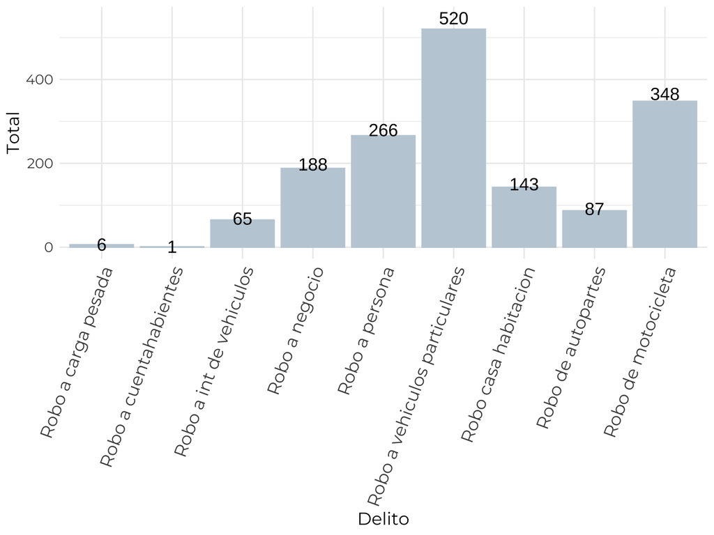

Fuente: Fiscalía del Estado de Jalisco.

### Carpetas de investigación de delitos patrimoniales seleccionados por zona geográfica, agosto de 2026

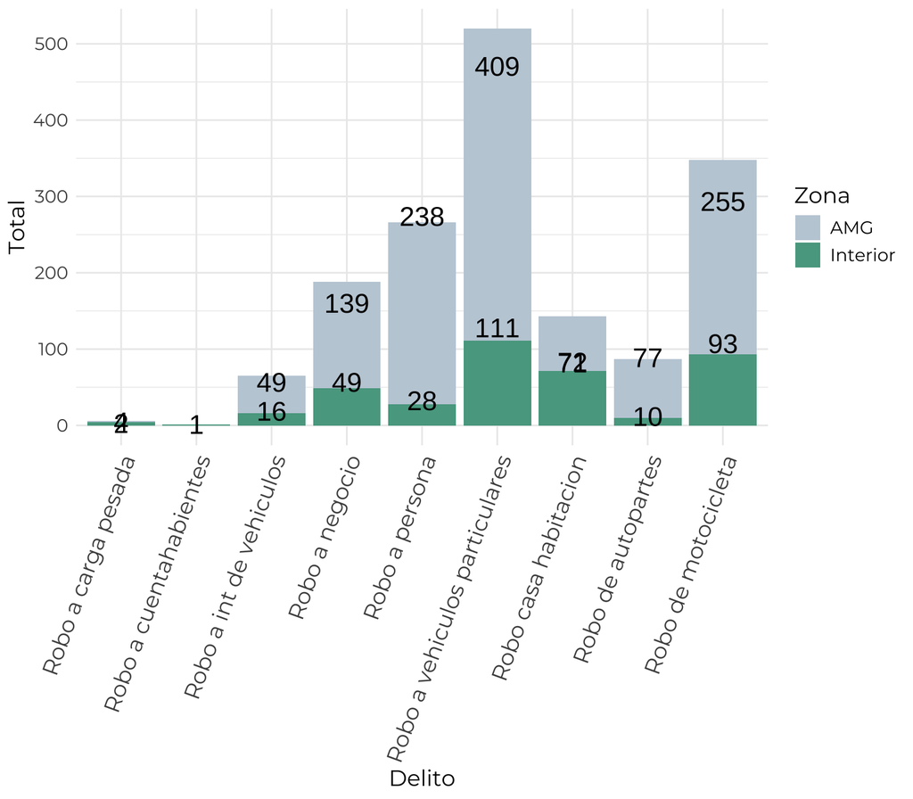

Fuente: Fiscalía del Estado de Jalisco.

### Carpetas de investigación de delitos patrimoniales seleccionados, según modalidad: con o sin violencia, agosto de 2026

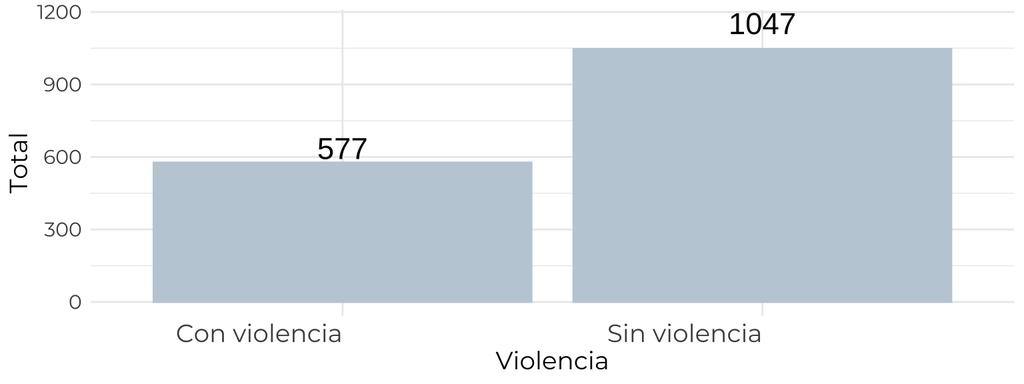

Fuente: Fiscalía del Estado de Jalisco.

[figure not shown]

La sección de delitos contra la vida presenta una selección de tres categorías de delitos. Nota: debido al trabajo de procesamiento en sitios de inhumación clandestina, se suman como víctimas de homicidio doloso a las personas localizadas en sitios de inhumación clandestina durante el periodo comprendido entre enero de 2018 a agosto de 2026.

| Concepto | Descripción |
| --- | --- |
| Homicidio doloso | Consiste en privar de la vida con intención a otra persona. |
| Feminicidio | Consiste en privar de la vida a una mujer por razones de género. Se entiende que existen razones de género cuando en la privación de la vida se presente alguna de las siguientes circunstancias: I- Exi… |
| Lesiones dolosas | Consiste en causar una alteración con intención a la salud de una persona. |

Fuente: Fiscalía del Estado de Jalisco.

### Carpetas de investigación por delitos contra la vida seleccionados, agosto de 2026

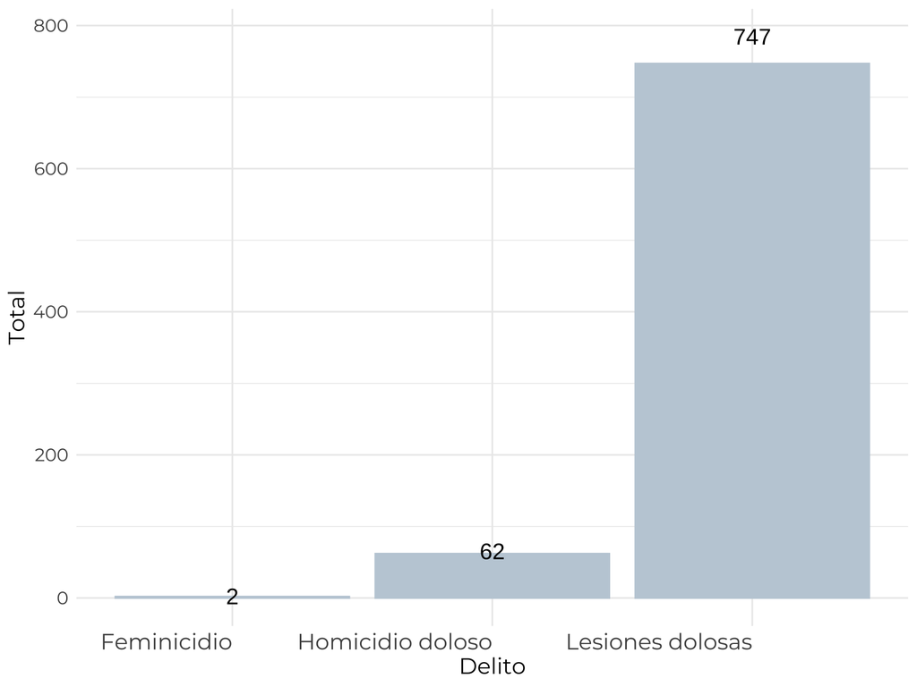

Fuente: Fiscalía del Estado de Jalisco.

### Tasa de carpetas de investigación de delitos contra la vida seleccionados por cada 100,000 habitantes, según zona geográfica, agosto de 2026

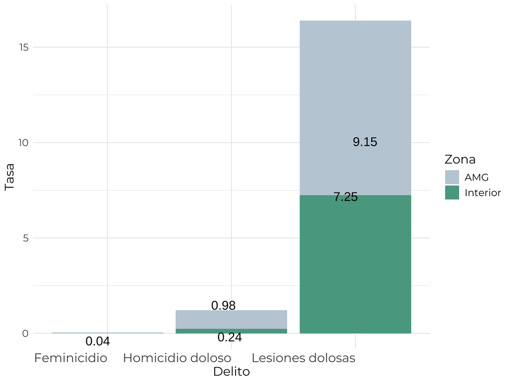

Nota: La tasa se obtiene al dividir el total de delitos en el período determinado entre la población total, y el resultado de esta operación se multiplica por 100,000.

Fuente: Fiscalía del Estado de Jalisco  
CONAPO. Reconstrucción y proyecciones de la población de los municipios de México 1990-2040.

## Mapa de tasa de carpetas de investigación de los 16 delitos seleccionados por cada 100,000 habitantes según municipio, agosto de 2026

[interactive chart not shown]

Nota: La tasa se obtiene al dividir el total de delitos en el período determinado entre la población total, y el resultado de esta operación se multiplica por 100,000. La población se toma de las proyecciones de población municipales (CONAPO).

Fuente: Fiscalía del Estado de Jalisco  
CONAPO. Reconstrucción y proyecciones de la población de los municipios de México 1990-2040.

Sitios de inhumación clandestina

A continuación, se presenta el número de sitios de inhumación clandestina registrados en Jalisco y el total preliminar de víctimas localizadas en la fecha de corte de la información.

### Sitios de inhumación clandestina registrados en Jalisco, al corte del 31 de agosto de 2026

| Mes de inicio de procesamiento | Número de sitios registrados | Total preliminar de víctimas localizadas |
| --- | --- | --- |
| ago-26 | 2 | 3 |
| jul-26 | 1 | 3 |
| jun-26 | 4 | 7 |
| may-26 | 9 | 30 |
| abr-26 | 7 | 66 |
| mar-26 | 6 | 12 |
| feb-26 | 3 | 8 |
| ene-26 | 2 | 2 |
| dic-25 | 1 | 2 |
| nov-25 | 3 | 5 |
| oct-25 | 3 | 5 |
| sep-25 | 5 | 38 |
| ago-25 | 2 | 37 |
| jul-25 | 5 | 10 |
| jun-25 | 1 | 1 |
| may-25 | 2 | 4 |
| abr-25 | 10 | 12 |
| mar-25 | 6 | 23 |
| feb-25 | 7 | 68 |
| ene-25 | 8 | 11 |
| dic-24 | 1 | 24 |
| nov-24 | 1 | 5 |
| oct-24 | 2 | 8 |
| sep-24 | 2 | 9 |
| jul-24 | 7 | 50 |
| jun-24 | 4 | 17 |
| abr-24 | 2 | 10 |
| mar-24 | 1 | 13 |
| feb-24 | 1 | 4 |
| dic-23 | 1 | 2 |

[output cut: 56 more lines]

Fuente: Vicefiscalía en Personas Desaparecidas. Sitios de inhumación clandestina en Jalisco. Información disponible en: https://fiscaliaenpersonasdesaparecidas.jalisco.gob.mx/registro-estatal-de-fosas-clandestinas/

Acerca de la plataforma de seguridad

Esta es una plataforma de divulgación de información sobre seguridad conformada por la cooperación entre el Gobierno de Jalisco, academia y actores de la sociedad civil; surge de la necesidad de poner a disposición de la comunidad datos abiertos, comprensibles, confiables y oportunos sobre las cifras de incidencia delictiva en el estado, y con ello contribuir en los procesos de política pública y toma de decisiones en materia de seguridad humana.

**Objetivo general:**

Recabar, procesar e integrar cifras sobre carpetas de investigación de delitos del fuero común seleccionados, proporcionadas por autoridades estatales, con el fin de difundir información a través de un espacio digital de fácil consulta y acceso para la sociedad.

**Fuentes actuales:** Fiscalía del Estado de Jalisco.

**Medio de verificación:** Carpetas de investigación.

**Periodicidad de actualización:** Mensual.